# Predict Bike Sharing Demand with AutoGluon Template

## Project: Predict Bike Sharing Demand with AutoGluon

This notebook is a template with each step that you need to complete for the project.

Please fill in your code where there are explicit `?` markers in the notebook. You are welcome to add more cells and code as you see fit.

Once you have completed all the code implementations, please export your notebook as a HTML file so the reviews can view your code. Make sure you have all outputs correctly outputted.

`File-> Export Notebook As... -> Export Notebook as HTML`

There is a writeup to complete as well after all code implememtation is done. Please answer all questions and attach the necessary tables and charts. You can complete the writeup in either markdown or PDF.

Completing the code template and writeup template will cover all of the rubric points for this project.

The rubric contains "Stand Out Suggestions" for enhancing the project beyond the minimum requirements. The stand out suggestions are optional. If you decide to pursue the "stand out suggestions", you can include the code in this notebook and also discuss the results in the writeup file.

## Step 1: Create an account with Kaggle

### Create Kaggle Account and download API key

Below is example of steps to get the API username and key. Each student will have their own username and key.

1. Open account settings.

2. Scroll down to API and click Create New API Token.

3. Open up `kaggle.json` and use the username and key.


## Step 2: Download the Kaggle dataset using the kaggle python library

### Open up Sagemaker Studio and use starter template

1. Notebook should be using a `ml.t3.medium` instance (2 vCPU + 4 GiB)
2. Notebook should be using kernal: `Python 3 (MXNet 1.8 Python 3.7 CPU Optimized)`

### Install packages

```python
!pip install -U pip
!pip install -U setuptools wheel
!pip install -U "mxnet<2.0.0" bokeh==2.0.1
!pip install autogluon --no-cache-dir
!pip install kaggle
!pip install pygraphviz
!pip install seaborn
# Without --no-cache-dir, smaller aws instances may have trouble installing
```

### Setup Kaggle API Key

```python
# create the .kaggle directory and an empty kaggle.json file
!mkdir -p ~/.kaggle
!touch ~/.kaggle/kaggle.json
!chmod 600 ~/.kaggle/kaggle.json
```

```python
# Fill in your user name and key from creating the kaggle account and API token file
import json
kaggle_username = "XXXXX"
kaggle_key = "XXXXX"

# Save API token the kaggle.json file
with open("/home/sagemaker-user/.kaggle/kaggle.json", "w") as f:
    f.write(json.dumps({"username": kaggle_username, "key": kaggle_key}))
```

### Download and explore dataset

### Go to the bike sharing demand competition and agree to the terms

```python
# Download the dataset, it will be in a .zip file so you'll need to unzip it as well.
!kaggle competitions download -c bike-sharing-demand
# If you already downloaded it you can use the -o command to overwrite the file
!unzip -o bike-sharing-demand.zip
```

```
bike-sharing-demand.zip: Skipping, found more recently modified local copy (use --force to force download)
Archive:  bike-sharing-demand.zip
  inflating: sampleSubmission.csv
  inflating: test.csv
  inflating: train.csv
```

```python
import pandas as pd
from autogluon.tabular import TabularPredictor
import matplotlib.pyplot as plt
import seaborn as sns
```

```python
# Create the train dataset in pandas by reading the csv
# Set the parsing of the datetime column so you can use some of the `dt` features in pandas later
train = pd.read_csv("train.csv")
train.head()
```

|  | datetime | season | holiday | workingday | weather | temp | atemp | humidity | windspeed | casual | registered | count |
| --- | --- | --- | --- | --- | --- | --- | --- | --- | --- | --- | --- | --- |
| 0 | 2011-01-01 00:00:00 | 1 | 0 | 0 | 1 | 9.84 | 14.395 | 81 | 0.0 | 3 | 13 | 16 |
| 1 | 2011-01-01 01:00:00 | 1 | 0 | 0 | 1 | 9.02 | 13.635 | 80 | 0.0 | 8 | 32 | 40 |
| 2 | 2011-01-01 02:00:00 | 1 | 0 | 0 | 1 | 9.02 | 13.635 | 80 | 0.0 | 5 | 27 | 32 |
| 3 | 2011-01-01 03:00:00 | 1 | 0 | 0 | 1 | 9.84 | 14.395 | 75 | 0.0 | 3 | 10 | 13 |
| 4 | 2011-01-01 04:00:00 | 1 | 0 | 0 | 1 | 9.84 | 14.395 | 75 | 0.0 | 0 | 1 | 1 |

```python
# Simple output of the train dataset to view some of the min/max/varition of the dataset features.
train.describe()
```

|  | season | holiday | workingday | weather | temp | atemp | humidity | windspeed | casual | registered | count |
| --- | --- | --- | --- | --- | --- | --- | --- | --- | --- | --- | --- |
| count | 10886.000000 | 10886.000000 | 10886.000000 | 10886.000000 | 10886.00000 | 10886.000000 | 10886.000000 | 10886.000000 | 10886.000000 | 10886.000000 | 10886.000000 |
| mean | 2.506614 | 0.028569 | 0.680875 | 1.418427 | 20.23086 | 23.655084 | 61.886460 | 12.799395 | 36.021955 | 155.552177 | 191.574132 |
| std | 1.116174 | 0.166599 | 0.466159 | 0.633839 | 7.79159 | 8.474601 | 19.245033 | 8.164537 | 49.960477 | 151.039033 | 181.144454 |
| min | 1.000000 | 0.000000 | 0.000000 | 1.000000 | 0.82000 | 0.760000 | 0.000000 | 0.000000 | 0.000000 | 0.000000 | 1.000000 |
| 25% | 2.000000 | 0.000000 | 0.000000 | 1.000000 | 13.94000 | 16.665000 | 47.000000 | 7.001500 | 4.000000 | 36.000000 | 42.000000 |
| 50% | 3.000000 | 0.000000 | 1.000000 | 1.000000 | 20.50000 | 24.240000 | 62.000000 | 12.998000 | 17.000000 | 118.000000 | 145.000000 |
| 75% | 4.000000 | 0.000000 | 1.000000 | 2.000000 | 26.24000 | 31.060000 | 77.000000 | 16.997900 | 49.000000 | 222.000000 | 284.000000 |
| max | 4.000000 | 1.000000 | 1.000000 | 4.000000 | 41.00000 | 45.455000 | 100.000000 | 56.996900 | 367.000000 | 886.000000 | 977.000000 |

```python
# Create the test pandas dataframe in pandas by reading the csv, remember to parse the datetime!
test = pd.read_csv("test.csv")
test.head()
```

|  | datetime | season | holiday | workingday | weather | temp | atemp | humidity | windspeed |
| --- | --- | --- | --- | --- | --- | --- | --- | --- | --- |
| 0 | 2011-01-20 00:00:00 | 1 | 0 | 1 | 1 | 10.66 | 11.365 | 56 | 26.0027 |
| 1 | 2011-01-20 01:00:00 | 1 | 0 | 1 | 1 | 10.66 | 13.635 | 56 | 0.0000 |
| 2 | 2011-01-20 02:00:00 | 1 | 0 | 1 | 1 | 10.66 | 13.635 | 56 | 0.0000 |
| 3 | 2011-01-20 03:00:00 | 1 | 0 | 1 | 1 | 10.66 | 12.880 | 56 | 11.0014 |
| 4 | 2011-01-20 04:00:00 | 1 | 0 | 1 | 1 | 10.66 | 12.880 | 56 | 11.0014 |

```python
# Same thing as train and test dataset
submission = pd.read_csv("sampleSubmission.csv")
submission.head()
```

|  | datetime | count |
| --- | --- | --- |
| 0 | 2011-01-20 00:00:00 | 0 |
| 1 | 2011-01-20 01:00:00 | 0 |
| 2 | 2011-01-20 02:00:00 | 0 |
| 3 | 2011-01-20 03:00:00 | 0 |
| 4 | 2011-01-20 04:00:00 | 0 |

## Step 3: Train a model using AutoGluon’s Tabular Prediction

```python
predictor = TabularPredictor(label="count", problem_type="regression", eval_metric="root_mean_squared_error").fit(
    train_data=train.drop(["casual", "registered"], axis=1),time_limit=600, presets="medium_quality_faster_train")
```

[output not shown]

[output cut: 17 more lines]

[output not shown]

```
[1000]	valid_set's rmse: 136.065
```

```
	-135.958	 = Validation score   (-root_mean_squared_error)
	2.73s	 = Training   runtime
	0.14s	 = Validation runtime
Fitting model: LightGBM ... Training model for up to 595.11s of the 595.11s of remaining time.
	-134.0804	 = Validation score   (-root_mean_squared_error)
	1.19s	 = Training   runtime
	0.04s	 = Validation runtime
Fitting model: RandomForestMSE ... Training model for up to 593.76s of the 593.76s of remaining time.
	-122.0128	 = Validation score   (-root_mean_squared_error)
	12.39s	 = Training   runtime
	0.15s	 = Validation runtime
Fitting model: CatBoost ... Training model for up to 580.97s of the 580.96s of remaining time.
	-134.2362	 = Validation score   (-root_mean_squared_error)
	6.95s	 = Training   runtime
	0.0s	 = Validation runtime
Fitting model: ExtraTreesMSE ... Training model for up to 573.99s of the 573.99s of remaining time.
	-128.4294	 = Validation score   (-root_mean_squared_error)
	6.59s	 = Training   runtime
	0.15s	 = Validation runtime
Fitting model: NeuralNetFastAI ... Training model for up to 566.91s of the 566.91s of remaining time.
	-136.5149	 = Validation score   (-root_mean_squared_error)
	12.48s	 = Training   runtime
	0.03s	 = Validation runtime
Fitting model: XGBoost ... Training model for up to 554.37s of the 554.37s of remaining time.
	-135.0751	 = Validation score   (-root_mean_squared_error)
	1.48s	 = Training   runtime
	0.03s	 = Validation runtime
Fitting model: NeuralNetTorch ... Training model for up to 552.85s of the 552.85s of remaining time.
	-140.0227	 = Validation score   (-root_mean_squared_error)
	31.22s	 = Training   runtime
	0.01s	 = Validation runtime
Fitting model: LightGBMLarge ... Training model for up to 521.61s of the 521.6s of remaining time.
	-132.1736	 = Validation score   (-root_mean_squared_error)
	1.44s	 = Training   runtime
	0.02s	 = Validation runtime
Fitting model: WeightedEnsemble_L2 ... Training model for up to 360.0s of the 519.97s of remaining time.
	-92.4421	 = Validation score   (-root_mean_squared_error)
	0.32s	 = Training   runtime
	0.0s	 = Validation runtime
AutoGluon training complete, total runtime = 80.37s ... Best model: "WeightedEnsemble_L2"
TabularPredictor saved. To load, use: predictor = TabularPredictor.load("AutogluonModels/ag-20240127_131755")
```

### Review AutoGluon's training run with ranking of models that did the best.

```python
predictor.fit_summary()
```

```
*** Summary of fit() ***
Estimated performance of each model:
                  model   score_val  pred_time_val   fit_time  pred_time_val_marginal  fit_time_marginal  stack_level  can_infer  fit_order
0        KNeighborsDist  -92.442085       0.016831   0.028614                0.016831           0.028614            1       True          2
1   WeightedEnsemble_L2  -92.442085       0.017497   0.348221                0.000666           0.319607            2       True         12
2        KNeighborsUnif -109.739422       0.017082   1.580897                0.017082           1.580897            1       True          1
3       RandomForestMSE -122.012844       0.145864  12.393788                0.145864          12.393788            1       True          5
4         ExtraTreesMSE -128.429416       0.146437   6.589551                0.146437           6.589551            1       True          7
5         LightGBMLarge -132.173561       0.024589   1.443592                0.024589           1.443592            1       True         11
6              LightGBM -134.080427       0.042571   1.190982                0.042571           1.190982            1       True          4
7              CatBoost -134.236163       0.004028   6.947863                0.004028           6.947863            1       True          6
8               XGBoost -135.075087       0.029150   1.475382                0.029150           1.475382            1       True          9
9            LightGBMXT -135.958034       0.141905   2.726145                0.141905           2.726145            1       True          3
10      NeuralNetFastAI -136.514902       0.034083  12.479125                0.034083          12.479125            1       True          8
11       NeuralNetTorch -140.022701       0.012478  31.221831                0.012478          31.221831            1       True         10
Number of models trained: 12
Types of models trained:
{'XGBoostModel', 'XTModel', 'LGBModel', 'TabularNeuralNetTorchModel', 'CatBoostModel', 'KNNModel', 'WeightedEnsembleModel', 'RFModel', 'NNFastAiTabularModel'}
Bagging used: False
Multi-layer stack-ensembling used: False
Feature Metadata (Processed):
(raw dtype, special dtypes):
('float', [])                : 3 | ['temp', 'atemp', 'windspeed']
('int', [])                  : 3 | ['season', 'weather', 'humidity']
('int', ['bool'])            : 2 | ['holiday', 'workingday']
('int', ['datetime_as_int']) : 5 | ['datetime', 'datetime.year', 'datetime.month', 'datetime.day', 'datetime.dayofweek']
*** End of fit() summary ***
```

[output not shown]

[output cut: 115 more lines]

[output not shown]

```python
predictor.get_model_best()
```

```
'WeightedEnsemble_L2'
```

```python
predictor.plot_ensemble_model()
```

```
'AutogluonModels/ag-20240127_131755/ensemble_model.png'
```

```python
predictor_score_val = predictor.leaderboard().loc[0,"score_val"]
```

```
                  model   score_val  pred_time_val   fit_time  pred_time_val_marginal  fit_time_marginal  stack_level  can_infer  fit_order
0        KNeighborsDist  -92.442085       0.016831   0.028614                0.016831           0.028614            1       True          2
1   WeightedEnsemble_L2  -92.442085       0.017497   0.348221                0.000666           0.319607            2       True         12
2        KNeighborsUnif -109.739422       0.017082   1.580897                0.017082           1.580897            1       True          1
3       RandomForestMSE -122.012844       0.145864  12.393788                0.145864          12.393788            1       True          5
4         ExtraTreesMSE -128.429416       0.146437   6.589551                0.146437           6.589551            1       True          7
5         LightGBMLarge -132.173561       0.024589   1.443592                0.024589           1.443592            1       True         11
6              LightGBM -134.080427       0.042571   1.190982                0.042571           1.190982            1       True          4
7              CatBoost -134.236163       0.004028   6.947863                0.004028           6.947863            1       True          6
8               XGBoost -135.075087       0.029150   1.475382                0.029150           1.475382            1       True          9
9            LightGBMXT -135.958034       0.141905   2.726145                0.141905           2.726145            1       True          3
10      NeuralNetFastAI -136.514902       0.034083  12.479125                0.034083          12.479125            1       True          8
11       NeuralNetTorch -140.022701       0.012478  31.221831                0.012478          31.221831            1       True         10
```

### Create predictions from test dataset

```python
predictions = predictor.predict(test)
predictions.head()
```

```
0    51.861626
1    56.686295
2    59.077763
3    60.468830
4    61.419930
Name: count, dtype: float32
```

#### NOTE: Kaggle will reject the submission if we don't set everything to be > 0.

```python
# Describe the `predictions` series to see if there are any negative values
predictions.describe()
```

```
count    6493.000000
mean      135.819412
std       132.525269
min         3.424214
25%        23.827692
50%        71.032265
75%       203.938919
max       537.853882
Name: count, dtype: float64
```

```python
# How many negative values do we have?
(predictions.values<0).sum()
```

```
0
```

```python
# Set them to zero
predictions[predictions.values<0] = 0
```

### Set predictions to submission dataframe, save, and submit

```python
submission["count"] = predictions
submission.to_csv("submission.csv", index=False)
```

```python
!kaggle competitions submit -c bike-sharing-demand -f submission.csv -m "first raw submission"
```

```
Successfully submitted to Bike Sharing Demand
```

#### View submission via the command line or in the web browser under the competition's page - `My Submissions`

```python
!kaggle competitions submissions -c bike-sharing-demand | tail -n +1 | head -n 6
```

```
fileName                     date                 description                        status    publicScore  privateScore
---------------------------  -------------------  ---------------------------------  --------  -----------  ------------
submission.csv               2024-01-27 13:19:18  first raw submission               complete  1.86412      1.86412
submission.csv               2024-01-27 12:42:24  first raw submission               complete  1.86412      1.86412
submission_new_hpo.csv       2024-01-27 12:24:47  new features with hyperparameters  complete  0.54224      0.54224
submission_new_features.csv  2024-01-27 12:23:20  new features                       complete  0.50942      0.50942
```

#### Initial score of `1.86412`

```python
predictor_score_test = 1.86412
```

## Step 4: Exploratory Data Analysis and Creating an additional feature

- Any additional feature will do, but a great suggestion would be to separate out the datetime into hour, day, or month parts.

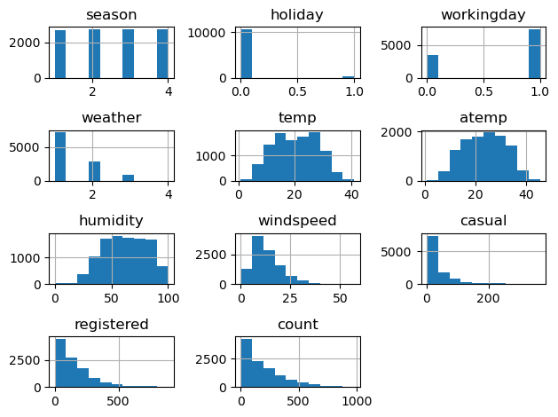

```python
# Create a histogram of all features to show the distribution of each one relative to the data. This is part of the exploritory data analysis
train.hist()
plt.tight_layout()
```

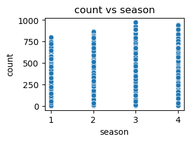

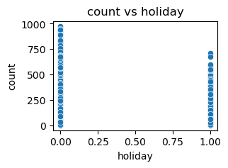

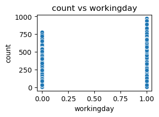

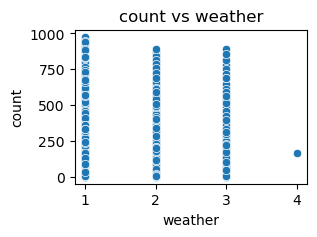

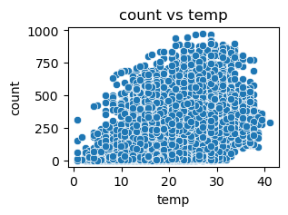

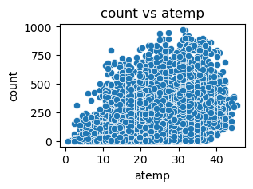

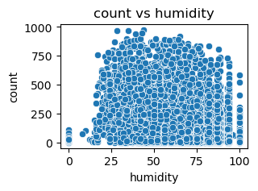

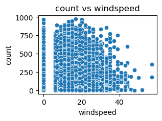

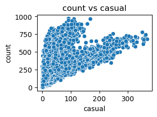

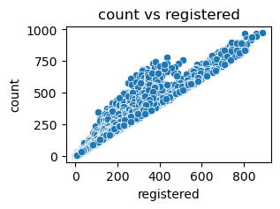

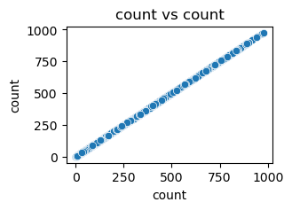

```python
for col in train.select_dtypes(include='number').columns:
    plt.figure(figsize=(3, 2))
    sns.scatterplot(data=train, x=col, y="count")
    plt.title(f'{"count"} vs {col}')
    plt.xlabel(col)
    plt.ylabel("count")
```

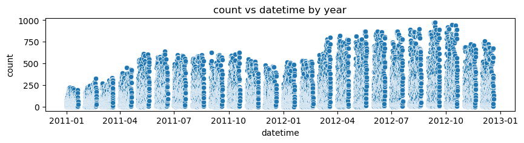

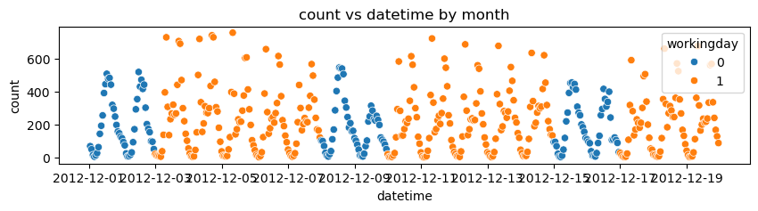

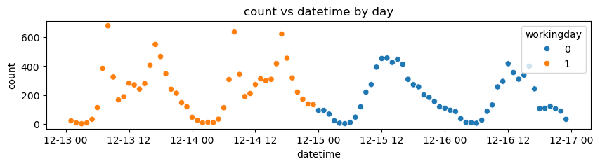

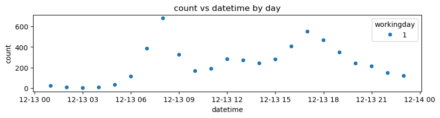

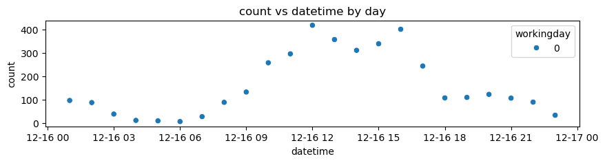

```python
train["datetime"] = pd.to_datetime(train["datetime"])
test["datetime"] = pd.to_datetime(test["datetime"])

plt.figure(figsize=(10, 2))
sns.scatterplot(data=train, x="datetime", y="count")
plt.title(f'{"count"} vs {"datetime"} by year')
plt.xlabel("datetime")
plt.ylabel("count")

plt.figure(figsize=(10, 2))
sns.scatterplot(data=train.query("'2012-12-01' < datetime < '2012-12-31'"), x="datetime", y="count", hue='workingday')
plt.title(f'{"count"} vs {"datetime"} by month')
plt.xlabel("datetime")
plt.ylabel("count")

plt.figure(figsize=(10, 2))
sns.scatterplot(data=train.query("'2012-12-13' < datetime < '2012-12-17'"), x="datetime", y="count", hue='workingday')
plt.title(f'{"count"} vs {"datetime"} by day')
plt.xlabel("datetime")
plt.ylabel("count")

plt.figure(figsize=(10, 2))
sns.scatterplot(data=train.query("'2012-12-13' < datetime < '2012-12-14'"), x="datetime", y="count", hue='workingday')
plt.title(f'{"count"} vs {"datetime"} by day')
plt.xlabel("datetime")
plt.ylabel("count")

plt.figure(figsize=(10, 2))
sns.scatterplot(data=train.query("'2012-12-16' < datetime < '2012-12-17'"), x="datetime", y="count", hue='workingday')
plt.title(f'{"count"} vs {"datetime"} by day')
plt.xlabel("datetime")
plt.ylabel("count")
```

```python
# create a new feature
train["year"] = train["datetime"].dt.year
train["month"] = train["datetime"].dt.month
train["day"] = train["datetime"].dt.day
train["hour"] = train["datetime"].dt.hour

test["year"] = test["datetime"].dt.year
test["month"] = test["datetime"].dt.month
test["day"] = test["datetime"].dt.day
test["hour"] = test["datetime"].dt.hour
```

## Make category types for these so models know they are not just numbers

- AutoGluon originally sees these as ints, but in reality they are int representations of a category.
- Setting the dtype to category will classify these as categories in AutoGluon.

```python
train["season"] = train["season"].astype("category")
train["weather"] = train["weather"].astype("category")
test["season"] = test["season"].astype("category")
test["weather"] = test["weather"].astype("category")
```

```python
# View are new feature
train.head()
```

|  | datetime | season | holiday | workingday | weather | temp | atemp | humidity | windspeed | casual | registered | count | year | month | day | hour |
| --- | --- | --- | --- | --- | --- | --- | --- | --- | --- | --- | --- | --- | --- | --- | --- | --- |
| 0 | 2011-01-01 00:00:00 | 1 | 0 | 0 | 1 | 9.84 | 14.395 | 81 | 0.0 | 3 | 13 | 16 | 2011 | 1 | 1 | 0 |
| 1 | 2011-01-01 01:00:00 | 1 | 0 | 0 | 1 | 9.02 | 13.635 | 80 | 0.0 | 8 | 32 | 40 | 2011 | 1 | 1 | 1 |
| 2 | 2011-01-01 02:00:00 | 1 | 0 | 0 | 1 | 9.02 | 13.635 | 80 | 0.0 | 5 | 27 | 32 | 2011 | 1 | 1 | 2 |
| 3 | 2011-01-01 03:00:00 | 1 | 0 | 0 | 1 | 9.84 | 14.395 | 75 | 0.0 | 3 | 10 | 13 | 2011 | 1 | 1 | 3 |
| 4 | 2011-01-01 04:00:00 | 1 | 0 | 0 | 1 | 9.84 | 14.395 | 75 | 0.0 | 0 | 1 | 1 | 2011 | 1 | 1 | 4 |

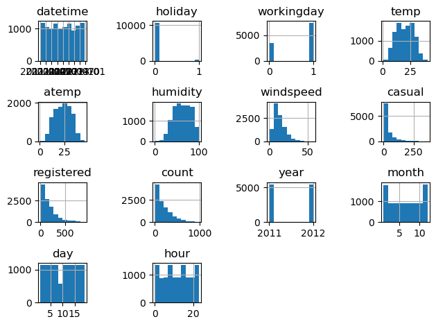

```python
# View histogram of all features again now with the hour feature
train.hist()
plt.tight_layout()
```

## Step 5: Rerun the model with the same settings as before, just with more features

```python
predictor_new_features = TabularPredictor(label="count", problem_type="regression", eval_metric="root_mean_squared_error").fit(
    train_data=train.drop(["casual", "registered"], axis=1),time_limit=600, presets="medium_quality_faster_train")
```

[output not shown]

[output cut: 21 more lines]

[output not shown]

```
[1000]	valid_set's rmse: 38.1093
[2000]	valid_set's rmse: 36.1484
[3000]	valid_set's rmse: 35.7331
[4000]	valid_set's rmse: 35.7493
```

```
	-35.6908	 = Validation score   (-root_mean_squared_error)
	5.71s	 = Training   runtime
	0.51s	 = Validation runtime
Fitting model: LightGBM ... Training model for up to 592.05s of the 592.04s of remaining time.
```

```
[1000]	valid_set's rmse: 35.1998
```

```
	-35.1309	 = Validation score   (-root_mean_squared_error)
	2.13s	 = Training   runtime
	0.2s	 = Validation runtime
Fitting model: RandomForestMSE ... Training model for up to 589.5s of the 589.5s of remaining time.
	-38.6054	 = Validation score   (-root_mean_squared_error)
	15.39s	 = Training   runtime
	0.19s	 = Validation runtime
Fitting model: CatBoost ... Training model for up to 573.65s of the 573.65s of remaining time.
	-35.1715	 = Validation score   (-root_mean_squared_error)
	191.3s	 = Training   runtime
	0.03s	 = Validation runtime
Fitting model: ExtraTreesMSE ... Training model for up to 382.28s of the 382.28s of remaining time.
	-39.5458	 = Validation score   (-root_mean_squared_error)
	7.39s	 = Training   runtime
	0.18s	 = Validation runtime
Fitting model: NeuralNetFastAI ... Training model for up to 374.39s of the 374.39s of remaining time.
	-44.1929	 = Validation score   (-root_mean_squared_error)
	14.05s	 = Training   runtime
	0.03s	 = Validation runtime
Fitting model: XGBoost ... Training model for up to 360.28s of the 360.28s of remaining time.
	-35.9444	 = Validation score   (-root_mean_squared_error)
	3.57s	 = Training   runtime
	0.13s	 = Validation runtime
Fitting model: NeuralNetTorch ... Training model for up to 356.54s of the 356.54s of remaining time.
	-38.5217	 = Validation score   (-root_mean_squared_error)
	59.38s	 = Training   runtime
	0.01s	 = Validation runtime
Fitting model: LightGBMLarge ... Training model for up to 297.13s of the 297.13s of remaining time.
```

```
[1000]	valid_set's rmse: 33.9932
```

```
	-33.9906	 = Validation score   (-root_mean_squared_error)
	3.66s	 = Training   runtime
	0.2s	 = Validation runtime
Fitting model: WeightedEnsemble_L2 ... Training model for up to 360.0s of the 292.57s of remaining time.
	-32.3896	 = Validation score   (-root_mean_squared_error)
	0.32s	 = Training   runtime
	0.0s	 = Validation runtime
AutoGluon training complete, total runtime = 307.79s ... Best model: "WeightedEnsemble_L2"
TabularPredictor saved. To load, use: predictor = TabularPredictor.load("AutogluonModels/ag-20240127_131929")
```

```python
predictor_new_features.fit_summary()
```

```
*** Summary of fit() ***
Estimated performance of each model:
                  model   score_val  pred_time_val    fit_time  pred_time_val_marginal  fit_time_marginal  stack_level  can_infer  fit_order
0   WeightedEnsemble_L2  -32.389627       1.088227  279.360121                0.000423           0.318527            2       True         12
1         LightGBMLarge  -33.990649       0.198712    3.664835                0.198712           3.664835            1       True         11
2              LightGBM  -35.130905       0.199929    2.133073                0.199929           2.133073            1       True          4
3              CatBoost  -35.171476       0.025886  191.297985                0.025886         191.297985            1       True          6
4            LightGBMXT  -35.690805       0.510445    5.705643                0.510445           5.705643            1       True          3
5               XGBoost  -35.944378       0.131675    3.573299                0.131675           3.573299            1       True          9
6        NeuralNetTorch  -38.521665       0.013742   59.383106                0.013742          59.383106            1       True         10
7       RandomForestMSE  -38.605365       0.192123   15.393701                0.192123          15.393701            1       True          5
8         ExtraTreesMSE  -39.545764       0.180117    7.387110                0.180117           7.387110            1       True          7
9       NeuralNetFastAI  -44.192931       0.032176   14.048934                0.032176          14.048934            1       True          8
10       KNeighborsDist  -92.442085       0.015221    0.023025                0.015221           0.023025            1       True          2
11       KNeighborsUnif -109.739422       0.014378    0.021336                0.014378           0.021336            1       True          1
Number of models trained: 12
Types of models trained:
{'XGBoostModel', 'XTModel', 'LGBModel', 'TabularNeuralNetTorchModel', 'CatBoostModel', 'KNNModel', 'WeightedEnsembleModel', 'RFModel', 'NNFastAiTabularModel'}
Bagging used: False
Multi-layer stack-ensembling used: False
Feature Metadata (Processed):
(raw dtype, special dtypes):
('category', [])             : 2 | ['season', 'weather']
('float', [])                : 3 | ['temp', 'atemp', 'windspeed']
('int', [])                  : 4 | ['humidity', 'month', 'day', 'hour']
('int', ['bool'])            : 3 | ['holiday', 'workingday', 'year']
('int', ['datetime_as_int']) : 3 | ['datetime', 'datetime.year', 'datetime.dayofweek']
*** End of fit() summary ***
```

[output not shown]

[output cut: 115 more lines]

[output not shown]

```python
predictor_new_features.get_model_best()
```

```
'WeightedEnsemble_L2'
```

```python
predictor_new_features.plot_ensemble_model()
```

```
'AutogluonModels/ag-20240127_131929/ensemble_model.png'
```

```python
predictor_new_features_score_val = predictor_new_features.leaderboard().loc[0,"score_val"]
```

```
                  model   score_val  pred_time_val    fit_time  pred_time_val_marginal  fit_time_marginal  stack_level  can_infer  fit_order
0   WeightedEnsemble_L2  -32.389627       1.088227  279.360121                0.000423           0.318527            2       True         12
1         LightGBMLarge  -33.990649       0.198712    3.664835                0.198712           3.664835            1       True         11
2              LightGBM  -35.130905       0.199929    2.133073                0.199929           2.133073            1       True          4
3              CatBoost  -35.171476       0.025886  191.297985                0.025886         191.297985            1       True          6
4            LightGBMXT  -35.690805       0.510445    5.705643                0.510445           5.705643            1       True          3
5               XGBoost  -35.944378       0.131675    3.573299                0.131675           3.573299            1       True          9
6        NeuralNetTorch  -38.521665       0.013742   59.383106                0.013742          59.383106            1       True         10
7       RandomForestMSE  -38.605365       0.192123   15.393701                0.192123          15.393701            1       True          5
8         ExtraTreesMSE  -39.545764       0.180117    7.387110                0.180117           7.387110            1       True          7
9       NeuralNetFastAI  -44.192931       0.032176   14.048934                0.032176          14.048934            1       True          8
10       KNeighborsDist  -92.442085       0.015221    0.023025                0.015221           0.023025            1       True          2
11       KNeighborsUnif -109.739422       0.014378    0.021336                0.014378           0.021336            1       True          1
```

```python
# Remember to set all negative values to zero
predictions_new_features = predictor_new_features.predict(test)
predictions_new_features[predictions_new_features.values<0] = 0
```

```python
# Same submitting
submission_new_features = submission.copy()
submission_new_features["count"] = predictions_new_features
submission_new_features.to_csv("submission_new_features.csv", index=False)
```

```python
!kaggle competitions submit -c bike-sharing-demand -f submission_new_features.csv -m "new features"
```

```
Successfully submitted to Bike Sharing Demand
```

```python
!kaggle competitions submissions -c bike-sharing-demand | tail -n +1 | head -n 6
```

```
fileName                     date                 description                        status    publicScore  privateScore
---------------------------  -------------------  ---------------------------------  --------  -----------  ------------
submission_new_features.csv  2024-01-27 13:24:45  new features                       complete  0.50942      0.50942
submission.csv               2024-01-27 13:19:18  first raw submission               complete  1.86412      1.86412
submission.csv               2024-01-27 12:42:24  first raw submission               complete  1.86412      1.86412
submission_new_hpo.csv       2024-01-27 12:24:47  new features with hyperparameters  complete  0.54224      0.54224
```

#### New Score of `0.50942`

```python
predictor_new_features_score_test = 0.50942
```

## Step 6: Hyper parameter optimization

- There are many options for hyper parameter optimization.
- Options are to change the AutoGluon higher level parameters or the individual model hyperparameters.
- The hyperparameters of the models themselves that are in AutoGluon. Those need the `hyperparameter` and `hyperparameter_tune_kwargs` arguments.

```python
# # https://sagemaker.readthedocs.io/en/stable/doc_utils/pretrainedmodels.html
# from sagemaker import hyperparameters

# gbm_options = hyperparameters.retrieve_default(
#     model_id="lightgbm-regression-model", model_version="*"
# )

# xgb_options = hyperparameters.retrieve_default(
#     model_id="xgboost-regression-model", model_version="*"
# )

# cat_options = hyperparameters.retrieve_default(
#     model_id="catboost-regression-model", model_version="*"
# )

# ll_options = hyperparameters.retrieve_default(
#     model_id="sklearn-regression-linear", model_version="*"
# )

# tt_options = hyperparameters.retrieve_default(
#     model_id="pytorch-tabtransformerregression-model)", model_version="*"
# )
```

```python
# import autogluon.core as ag

# gbm_options = {  # specifies non-default hyperparameter values for lightGBM gradient boosted trees
#     'num_boost_round': 100,  # number of boosting rounds (controls training time of GBM models)
#     'num_leaves': ag.space.Int(lower=26, upper=66, default=36)  # number of leaves in trees (integer hyperparameter)
# }

# nn_options = {  # specifies non-default hyperparameter values for neural network models
#     'num_epochs': 10,  # number of training epochs (controls training time of NN models)
#     'learning_rate': ag.Real(1e-4, 1e-2, default=5e-4, log=True),  # learning rate used in training (real-valued hyperparameter searched on log-scale)
#     'activation': ag.Categorical('relu', 'softrelu', 'tanh'),  # activation function used in NN (categorical hyperparameter, default = first entry)
#     'dropout_prob': ag.Real(0.0, 0.5, default=0.1),  # dropout probability (real-valued hyperparameter)
# }

# xgb_options = {
#     'n_estimators': ag.space.Int(lower=100, upper=400, default=100),
#     'max_depth': ag.space.Int(lower=4, upper=12, default=6), # Maximum depth of each tree (default is 6)
#     'learning_rate': ag.space.Real(1e-4, 1e-2, default=5e-4, log=True)
# }

# cat_options = {
#     'iterations' : 100,
#     'learning_rate': ag.space.Real(1e-4, 1e-2, default=5e-4, log=True),
#     'depth' : ag.space.Int(lower=6, upper=10)
# }

# hyperparameters = { # hyperparameters of each model type
#     'GBM': gbm_options,
#     # 'NN_TORCH': nn_options,  # NOTE: comment this line out if you get errors on Mac OSX
#     'XGB': xgb_options,
#     'CAT': cat_options,
# }

# num_trials = 5  # try at most 5 different hyperparameter configurations for each type of model
# search_strategy = 'auto'  # to tune hyperparameters using random search routine with a local scheduler

# hyperparameter_tune_kwargs = {  # HPO is not performed unless hyperparameter_tune_kwargs is specified
#     'num_trials': num_trials,
#     'scheduler' : 'local',
#     'searcher': search_strategy,
# }  # Refer to TabularPredictor.fit docstring for all valid }
```

```python
import autogluon.core as ag

gbm_options = {  # specifies non-default hyperparameter values for lightGBM gradient boosted trees
    'num_leaves': ag.space.Int(lower=26, upper=66, default=36)  # number of leaves in trees (integer hyperparameter)
}

xgb_options = {
    'max_depth': ag.space.Int(lower=4, upper=12, default=6), # Maximum depth of each tree (default is 6)
}

cat_options = {
    'iterations' : 100,
    'depth' : ag.space.Int(lower=6, upper=10)
}

hyperparameters = { # hyperparameters of each model type
    'GBM': gbm_options,
    'XGB': xgb_options,
    'CAT': cat_options,
}

num_trials = 5  # try at most 5 different hyperparameter configurations for each type of model
search_strategy = 'auto'  # to tune hyperparameters using random search routine with a local scheduler

hyperparameter_tune_kwargs = {  # HPO is not performed unless hyperparameter_tune_kwargs is specified
    'num_trials': num_trials,
    'scheduler' : 'local',
    'searcher': search_strategy,
}  # Refer to TabularPredictor.fit docstring for all valid }
```

```python
predictor_new_hpo = TabularPredictor(label="count", problem_type="regression", eval_metric="root_mean_squared_error").fit(
    train_data=train.drop(["casual", "registered"], axis=1),time_limit=600, presets="medium_quality_faster_train",
    hyperparameters=hyperparameters, hyperparameter_tune_kwargs=hyperparameter_tune_kwargs)
```

[output not shown]

[output cut: 9 more lines]

```
	13 features in original data used to generate 15 features in processed data.
	Train Data (Processed) Memory Usage: 0.8 MB (0.0% of available memory)
Data preprocessing and feature engineering runtime = 0.57s ...
AutoGluon will gauge predictive performance using evaluation metric: 'root_mean_squared_error'
	This metric's sign has been flipped to adhere to being higher_is_better. The metric score can be multiplied by -1 to get the metric value.
	To change this, specify the eval_metric parameter of Predictor()
Automatically generating train/validation split with holdout_frac=0.2, Train Rows: 8708, Val Rows: 2178
User-specified model hyperparameters to be fit:
{
	'GBM': {'num_leaves': Int: lower=26, upper=66},
	'XGB': {'max_depth': Int: lower=4, upper=12},
	'CAT': {'iterations': 100, 'depth': Int: lower=6, upper=10},
}
Fitting 3 L1 models ...
Hyperparameter tuning model: LightGBM ... Tuning model for up to 179.83s of the 599.43s of remaining time.
```

```
[1000]	valid_set's rmse: 36.1872
[1000]	valid_set's rmse: 36.7105
[1000]	valid_set's rmse: 36.4728
[1000]	valid_set's rmse: 41.7885
[2000]	valid_set's rmse: 38.9406
[3000]	valid_set's rmse: 38.1327
[4000]	valid_set's rmse: 37.8189
[5000]	valid_set's rmse: 37.545
[6000]	valid_set's rmse: 37.3607
[7000]	valid_set's rmse: 37.2889
[8000]	valid_set's rmse: 37.2154
[9000]	valid_set's rmse: 37.1821
[10000]	valid_set's rmse: 37.0815
[1000]	valid_set's rmse: 36.0364
[2000]	valid_set's rmse: 36.0593
```

```
Fitted model: LightGBM/T1 ...
	-36.0754	 = Validation score   (-root_mean_squared_error)
	2.32s	 = Training   runtime
	0.39s	 = Validation runtime
Fitted model: LightGBM/T2 ...
	-36.6503	 = Validation score   (-root_mean_squared_error)
	1.49s	 = Training   runtime
	0.19s	 = Validation runtime
Fitted model: LightGBM/T3 ...
	-36.4275	 = Validation score   (-root_mean_squared_error)
	3.23s	 = Training   runtime
	0.5s	 = Validation runtime
Fitted model: LightGBM/T4 ...
	-37.0815	 = Validation score   (-root_mean_squared_error)
	11.26s	 = Training   runtime
	3.8s	 = Validation runtime
Fitted model: LightGBM/T5 ...
	-35.9477	 = Validation score   (-root_mean_squared_error)
	3.1s	 = Training   runtime
	0.49s	 = Validation runtime
Hyperparameter tuning model: CatBoost ... Tuning model for up to 179.83s of the 568.88s of remaining time.
```

```
Fitted model: CatBoost/T1 ...
	-56.3694	 = Validation score   (-root_mean_squared_error)
	0.49s	 = Training   runtime
	0.01s	 = Validation runtime
Fitted model: CatBoost/T2 ...
	-39.8266	 = Validation score   (-root_mean_squared_error)
	1.56s	 = Training   runtime
	0.01s	 = Validation runtime
Fitted model: CatBoost/T3 ...
	-60.5189	 = Validation score   (-root_mean_squared_error)
	1.05s	 = Training   runtime
	0.02s	 = Validation runtime
Fitted model: CatBoost/T4 ...
	-40.3679	 = Validation score   (-root_mean_squared_error)
	0.71s	 = Training   runtime
	0.0s	 = Validation runtime
Fitted model: CatBoost/T5 ...
	-72.0927	 = Validation score   (-root_mean_squared_error)
	0.41s	 = Training   runtime
	0.0s	 = Validation runtime
Hyperparameter tuning model: XGBoost ... Tuning model for up to 179.83s of the 564.47s of remaining time.
```

```
Fitted model: XGBoost/T1 ...
	-38.0903	 = Validation score   (-root_mean_squared_error)
	4.18s	 = Training   runtime
	0.15s	 = Validation runtime
Fitted model: XGBoost/T2 ...
	-37.4876	 = Validation score   (-root_mean_squared_error)
	3.06s	 = Training   runtime
	0.11s	 = Validation runtime
Fitted model: XGBoost/T3 ...
	-37.1114	 = Validation score   (-root_mean_squared_error)
	10.43s	 = Training   runtime
	1.03s	 = Validation runtime
Fitted model: XGBoost/T4 ...
	-40.2433	 = Validation score   (-root_mean_squared_error)
	3.3s	 = Training   runtime
	0.06s	 = Validation runtime
Fitted model: XGBoost/T5 ...
	-40.7312	 = Validation score   (-root_mean_squared_error)
	6.94s	 = Training   runtime
	0.27s	 = Validation runtime
Fitting model: WeightedEnsemble_L2 ... Training model for up to 360.0s of the 526.95s of remaining time.
	-35.0836	 = Validation score   (-root_mean_squared_error)
	0.45s	 = Training   runtime
	0.0s	 = Validation runtime
AutoGluon training complete, total runtime = 73.53s ... Best model: "WeightedEnsemble_L2"
TabularPredictor saved. To load, use: predictor = TabularPredictor.load("AutogluonModels/ag-20240127_132447")
```

```python
predictor_new_hpo.fit_summary()
```

```
*** Summary of fit() ***
Estimated performance of each model:
                  model  score_val  pred_time_val   fit_time  pred_time_val_marginal  fit_time_marginal  stack_level  can_infer  fit_order
0   WeightedEnsemble_L2 -35.083550       3.026201  32.837998                0.000583           0.446487            2       True         16
1           LightGBM/T5 -35.947692       0.494385   3.097085                0.494385           3.097085            1       True          5
2           LightGBM/T1 -36.075438       0.385201   2.318270                0.385201           2.318270            1       True          1
3           LightGBM/T3 -36.427516       0.504449   3.234132                0.504449           3.234132            1       True          3
4           LightGBM/T2 -36.650340       0.186540   1.487114                0.186540           1.487114            1       True          2
5           LightGBM/T4 -37.081500       3.797553  11.258155                3.797553          11.258155            1       True          4
6            XGBoost/T3 -37.111413       1.029891  10.430059                1.029891          10.430059            1       True         13
7            XGBoost/T2 -37.487626       0.109468   3.058879                0.109468           3.058879            1       True         12
8            XGBoost/T1 -38.090316       0.152804   4.176373                0.152804           4.176373            1       True         11
9           CatBoost/T2 -39.826641       0.006763   1.559829                0.006763           1.559829            1       True          7
10           XGBoost/T4 -40.243343       0.055819   3.303574                0.055819           3.303574            1       True         14
11          CatBoost/T4 -40.367873       0.004440   0.712211                0.004440           0.712211            1       True          9
12           XGBoost/T5 -40.731194       0.267906   6.936267                0.267906           6.936267            1       True         15
13          CatBoost/T1 -56.369359       0.005911   0.490391                0.005911           0.490391            1       True          6
14          CatBoost/T3 -60.518887       0.015028   1.050778                0.015028           1.050778            1       True          8
15          CatBoost/T5 -72.092699       0.004023   0.413574                0.004023           0.413574            1       True         10
Number of models trained: 16
Types of models trained:
{'XGBoostModel', 'WeightedEnsembleModel', 'LGBModel', 'CatBoostModel'}
Bagging used: False
Multi-layer stack-ensembling used: False
Feature Metadata (Processed):
(raw dtype, special dtypes):
('category', [])             : 2 | ['season', 'weather']
('float', [])                : 3 | ['temp', 'atemp', 'windspeed']
('int', [])                  : 4 | ['humidity', 'month', 'day', 'hour']
('int', ['bool'])            : 3 | ['holiday', 'workingday', 'year']
('int', ['datetime_as_int']) : 3 | ['datetime', 'datetime.year', 'datetime.dayofweek']
*** End of fit() summary ***
```

[output not shown]

[output cut: 185 more lines]

[output not shown]

```python
predictor_new_hpo.get_model_best()
```

```
'WeightedEnsemble_L2'
```

```python
predictor_new_hpo.plot_ensemble_model()
```

```
'AutogluonModels/ag-20240127_132447/ensemble_model.png'
```

```python
predictor_new_hpo_score_val = predictor_new_hpo.leaderboard().loc[0,"score_val"]
```

```
                  model  score_val  pred_time_val   fit_time  pred_time_val_marginal  fit_time_marginal  stack_level  can_infer  fit_order
0   WeightedEnsemble_L2 -35.083550       3.026201  32.837998                0.000583           0.446487            2       True         16
1           LightGBM/T5 -35.947692       0.494385   3.097085                0.494385           3.097085            1       True          5
2           LightGBM/T1 -36.075438       0.385201   2.318270                0.385201           2.318270            1       True          1
3           LightGBM/T3 -36.427516       0.504449   3.234132                0.504449           3.234132            1       True          3
4           LightGBM/T2 -36.650340       0.186540   1.487114                0.186540           1.487114            1       True          2
5           LightGBM/T4 -37.081500       3.797553  11.258155                3.797553          11.258155            1       True          4
6            XGBoost/T3 -37.111413       1.029891  10.430059                1.029891          10.430059            1       True         13
7            XGBoost/T2 -37.487626       0.109468   3.058879                0.109468           3.058879            1       True         12
8            XGBoost/T1 -38.090316       0.152804   4.176373                0.152804           4.176373            1       True         11
9           CatBoost/T2 -39.826641       0.006763   1.559829                0.006763           1.559829            1       True          7
10           XGBoost/T4 -40.243343       0.055819   3.303574                0.055819           3.303574            1       True         14
11          CatBoost/T4 -40.367873       0.004440   0.712211                0.004440           0.712211            1       True          9
12           XGBoost/T5 -40.731194       0.267906   6.936267                0.267906           6.936267            1       True         15
13          CatBoost/T1 -56.369359       0.005911   0.490391                0.005911           0.490391            1       True          6
14          CatBoost/T3 -60.518887       0.015028   1.050778                0.015028           1.050778            1       True          8
15          CatBoost/T5 -72.092699       0.004023   0.413574                0.004023           0.413574            1       True         10
```

```python
# Remember to set all negative values to zero
predictions_new_hpo = predictor_new_hpo.predict(test)
predictions_new_hpo[predictions_new_hpo.values<0] = 0
```

```python
# Same submitting predictions
submission_new_hpo = submission.copy()
submission_new_hpo["count"] = predictions_new_hpo
submission_new_hpo.to_csv("submission_new_hpo.csv", index=False)
```

```python
!kaggle competitions submit -c bike-sharing-demand -f submission_new_hpo.csv -m "new features with hyperparameters"
```

```
Successfully submitted to Bike Sharing Demand
```

```python
!kaggle competitions submissions -c bike-sharing-demand | tail -n +1 | head -n 6
```

```
fileName                     date                 description                        status    publicScore  privateScore
---------------------------  -------------------  ---------------------------------  --------  -----------  ------------
submission_new_hpo.csv       2024-01-27 13:26:12  new features with hyperparameters  complete  0.54224      0.54224
submission_new_features.csv  2024-01-27 13:24:45  new features                       complete  0.50942      0.50942
submission.csv               2024-01-27 13:19:18  first raw submission               complete  1.86412      1.86412
submission.csv               2024-01-27 12:42:24  first raw submission               complete  1.86412      1.86412
tail: write error: Broken pipe
```

#### New Score of `0.54224`

```python
predictor_new_hpo_score_test = 0.54224
```

## Step 7: Write a Report

### Refer to the markdown file for the full report

### Creating plots and table for report

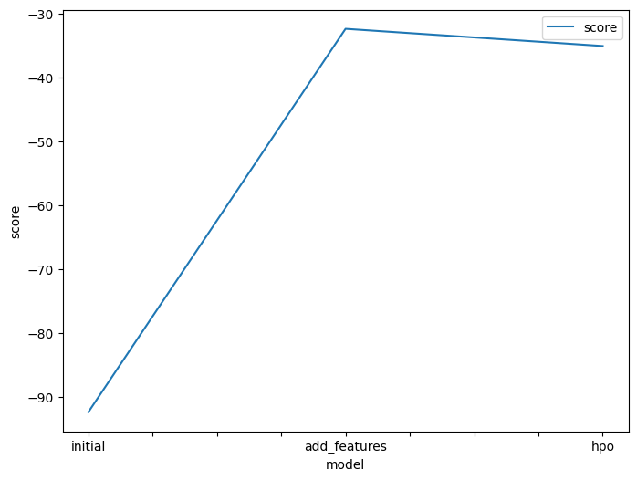

```python
# Taking the top model score from each training run and creating a line plot to show improvement
# You can create these in the notebook and save them to PNG or use some other tool (e.g. google sheets, excel)
fig = pd.DataFrame(
    {
        "model": ["initial", "add_features", "hpo"],
        "score": [predictor_score_val, predictor_new_features_score_val, predictor_new_hpo_score_val]
    }
).plot(x="model", y="score", figsize=(8, 6)).get_figure()
plt.xlabel("model")
plt.ylabel("score")
fig.savefig('model_train_score.png')
```

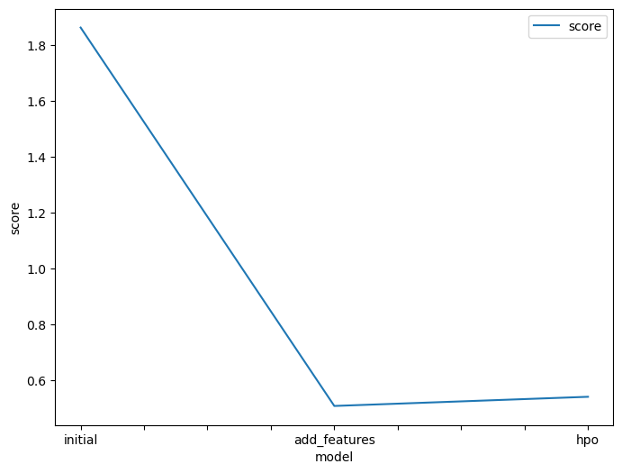

```python
# Take the 3 kaggle scores and creating a line plot to show improvement
fig = pd.DataFrame(
    {
        "test_eval": ["initial", "add_features", "hpo"],
        "score": [predictor_score_test, predictor_new_features_score_test, predictor_new_hpo_score_test]
    }
).plot(x="test_eval", y="score", figsize=(8, 6)).get_figure()
plt.xlabel("model")
plt.ylabel("score")
fig.savefig('model_test_score.png')
```

### Hyperparameter table

```python
# The 3 hyperparameters we tuned with the kaggle score as the result
pd.DataFrame({
    "model": ["initial", "add_features", "hpo"],
    "hpo1": ["default", "default", "GBM - num_leaves, XGB - max_depth, CAT - depth"],
    "hpo2": ["default", "default", "GBM - num_leaves, XGB - max_depth, CAT - depth"],
    "hpo3": ["default", "default", "GBM - num_leaves, XGB - max_depth, CAT - depth"],
    "score": [predictor_score_test, predictor_new_features_score_test, predictor_new_hpo_score_test]
})
```

|  | model | hpo1 | hpo2 | hpo3 | score |
| --- | --- | --- | --- | --- | --- |
| 0 | initial | default | default | default | 1.86412 |
| 1 | add_features | default | default | default | 0.50942 |
| 2 | hpo | GBM - num_leaves, XGB - max_depth, CAT - depth | GBM - num_leaves, XGB - max_depth, CAT - depth | GBM - num_leaves, XGB - max_depth, CAT - depth | 0.54224 |